# Psychological Health and Unemployment

Iqbal Hossain

2026-03-02

# 1. Introduction

Job loss is often seen as an immediate psychological shock, but recent literature suggests a more nuanced “honeymoon–hangover” pattern (Boswell, Boudreau, and Tichy 2005).

The report examines changes in mental health over the course of unemployment in Germany. Unemployment may initially bring short-term relief from job stress, followed by longer-term “scarring” effects on mental health (Clark, Georgellis, and Sanfey 2001; Hetschko, Knabe, and Schöb 2014). The analysis also explores how social support, especially marital status, can buffer these negative consequences (Young 2012; Stroebe, Schut, and Stroebe 2007).

## **Research Question:** *How does unemployment duration affect mental health, and does social support moderate these effects?*

# 2. Data Analysis

## 2.1 Sample and Data Management

This analysis utilizes the SOEP (Socio-Economic Panel) teaching data (v40). Three primary datasets (`pl`, `health`, and `pequiv`) are merged to create a comprehensive longitudinal panel. Strict exclusion criteria was applied, removing missing values and restricting the sample to individuals with valid employment and demographic data.

```r
# filter specific variables when loading
# plb0022_h  Employment status [harmonised]
# plh0182    Current Life Satisfaction
# plh0175    satisfaction with household income
# mh_nbs     Mental Health - z-transformed ( > 50 good, < 50 not)
# e11102     Employment Status of Individual
# m11125     Satisfaction with Health
# d11104     Marital Status of Individual
# Later added
# l11102     Region (east 2 or west 1)
# d11109     Number of Years of Education
# d11107     Number of Children in HH

pl     <- read_dta("SOEP Teaching v40/pl.dta",     col_select = c(pid, syear, plb0022_h, plh0182, plh0175))
health <- read_dta("SOEP Teaching v40/health.dta", col_select = c(pid, syear, mh_nbs))
pequiv <- read_dta("SOEP Teaching v40/pequiv.dta", col_select = c(pid, syear, e11102, m11125, d11104, l11102, d11109, d11107))

# check
table(pequiv$e11102, useNA = "ifany")
attr(pequiv$e11102, "labels")

# merge data
pl2     <- pl     %>% mutate(pid = as.numeric(zap_labels(pid)), syear = as.integer(zap_labels(syear)))
health2 <- health %>% mutate(pid = as.numeric(zap_labels(pid)), syear = as.integer(zap_labels(syear)))
pequiv2 <- pequiv %>% mutate(pid = as.numeric(zap_labels(pid)), syear = as.integer(zap_labels(syear)))

SOEP <- pl2 %>%
  inner_join(health2, by = c("pid", "syear")) %>%
  inner_join(pequiv2, by = c("pid", "syear"))

# give the variables nice names
SOEP <- SOEP %>%
  rename(
    emp_status_harmonized  = plb0022_h,   # harmonised employment status
    emp_status_raw         = e11102,      # raw employment status
    life_satisfaction      = plh0182,     # current life satisfaction
    hh_income_satisfaction = plh0175,     # satisfaction with household income
    mental_health_nbs      = mh_nbs,      # mental health (NBS)
    health_satisfaction    = m11125,      # satisfaction with health
    marital_status         = d11104,      # marital status
    no_of_children         = d11107,      # number of Children in HH
    region                 = l11102,      # Region (east or west)
    education              = d11109       # Number of Years of Education
  )

# filter out values that are not useful
SOEP_clean <- SOEP %>%
  filter(
    emp_status_harmonized  > 0,      # removes negative missings
    life_satisfaction      >= 0,     # 0–10 scale, keep 0
    hh_income_satisfaction >= 0,     # 0–10 scale, keep 0
    mental_health_nbs      >= 0,     # scale, keep valid values
    emp_status_raw         >= 0,     # keep 0/1
    health_satisfaction    >= 0,     # 0–10 scale, keep 0
    marital_status         > 0,      # marital status categories (start at 1)
    no_of_children         >= 0,     # can have no children
    region                 > 0,      # no zero region
    education              > 0       # there is no zero
  )

# check NA
colSums(is.na(SOEP_clean))

# remove labels
SOEP_clean <- SOEP_clean %>%
  mutate(across(where(haven::is.labelled), ~as.numeric(zap_labels(.))))
```

## 2.2 Variables

To isolate the psychological effect of unemployment duration, a robust set of variables is used, incorporating both key indicators and some socio-economic controls:

- **Primary Dependent Variable:** `mental_health_nbs` (Norm-Based Score, centered around 50).
- **Primary Independent Variable:** `unemployment_duration` (Years spent unemployed continuously).
- **Primary Moderator:** `marital_status` (Categorical: Single, Married, Divorced, Widowed).
- **Control Variables:** `life_satisfaction`, `health_satisfaction`, `hh_income_satisfaction`, `no_of_children`, `education`, `region`.

## 2.3 Summary Statistics

The table below outlines the descriptive statistics of the continuous variables. Notably, the mean mental health score centers near the expected NBS average of 50.

```r
# create a summary table of the continuous variables
cont_table <- SOEP_clean %>%
  select(life_satisfaction, mental_health_nbs, health_satisfaction, hh_income_satisfaction) %>%
  summarise(
    across(everything(), list(
      Mean     = ~mean(., na.rm = TRUE),
      Median   = ~median(., na.rm = TRUE),
      SD       = ~sd(., na.rm = TRUE),
      Skewness = ~skewness(., na.rm = TRUE),
      Min      = ~min(., na.rm = TRUE),
      Max      = ~max(., na.rm = TRUE)
    ))
  ) %>%
  pivot_longer(cols = everything(),
               names_to = c("Variable", "Stat"),
               names_pattern = "(.*)_(.*)") %>%
  pivot_wider(names_from = Stat, values_from = value)

kable(cont_table, digits = 2, caption = "Table 1: Descriptive Statistics (Continuous)")
```

Table 1: Descriptive Statistics (Continuous)

| Variable | Mean | Median | SD | Skewness | Min | Max |
| --- | --- | --- | --- | --- | --- | --- |
| life_satisfaction | 7.21 | 8.00 | 1.73 | -1.00 | 0.00 | 10.00 |
| mental_health_nbs | 50.61 | 50.26 | 9.79 | -0.32 | 1.41 | 68.58 |
| health_satisfaction | 6.68 | 7.00 | 2.19 | -0.74 | 0.00 | 10.00 |
| hh_income_satisfaction | 6.67 | 7.00 | 2.24 | -0.73 | 0.00 | 10.00 |

### Missing Data Summary

```r
# missing data summary
SOEP_clean %>%
  summarise(across(everything(), ~sum(is.na(.)))) %>%
  pivot_longer(everything(), names_to = "Variable", values_to = "Missing") %>%
  kable(caption = "Table 2: Missing Values per Variable (Post-Cleaning)")
```

Table 2: Missing Values per Variable (Post-Cleaning)

| Variable | Missing |
| --- | --- |
| pid | 0 |
| syear | 0 |
| emp_status_harmonized | 0 |
| hh_income_satisfaction | 0 |
| life_satisfaction | 0 |
| mental_health_nbs | 0 |
| marital_status | 0 |
| no_of_children | 0 |
| education | 0 |
| emp_status_raw | 0 |
| region | 0 |
| health_satisfaction | 0 |

## 2.4 Exploratory Data Analysis & Visualizations

### 2.4.1 Distributions

A visual inspection of key continuous variables confirms relatively normal distributions for mental health, and left-skewed distributions for satisfaction metrics (as is typical in subjective well-being data).

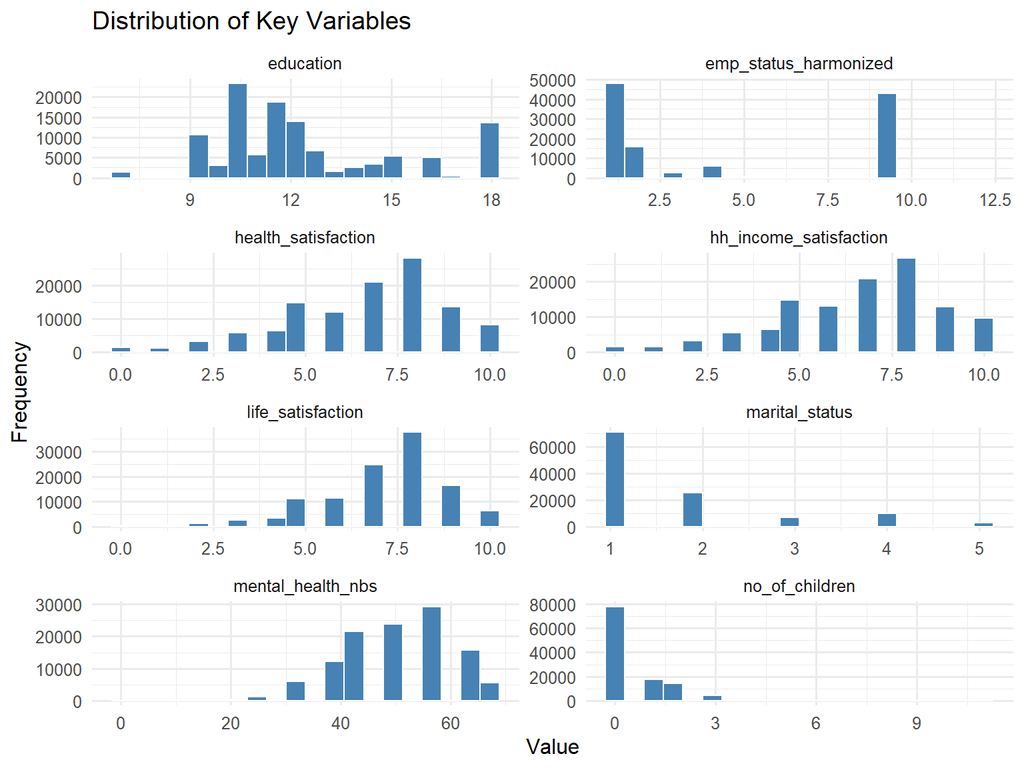

```r
# crate a distribution histogram of key variables
SOEP_clean %>%
  # select variables to visualize
  select(emp_status_harmonized, life_satisfaction, mental_health_nbs, health_satisfaction, hh_income_satisfaction, marital_status, no_of_children, education) %>%
  # remove rows with NAs so they don't break the histogram
  drop_na() %>%
  # ensure all are numeric
  mutate(across(everything(), as.numeric)) %>%
  # pivot for ggplot
  pivot_longer(cols = everything(), names_to = "Variable", values_to = "Value") %>%
  #plot
  ggplot(aes(x = Value)) +
  geom_histogram(fill = "steelblue", color = "white", bins = 20) +
  facet_wrap(~ Variable, scales = "free", ncol = 2) +
  theme_minimal(base_size = 12) +
  labs(
    title = "Distribution of Key Variables",
    x = "Value",
    y = "Frequency"
  )
```

### 2.4.2 Correlation Analysis

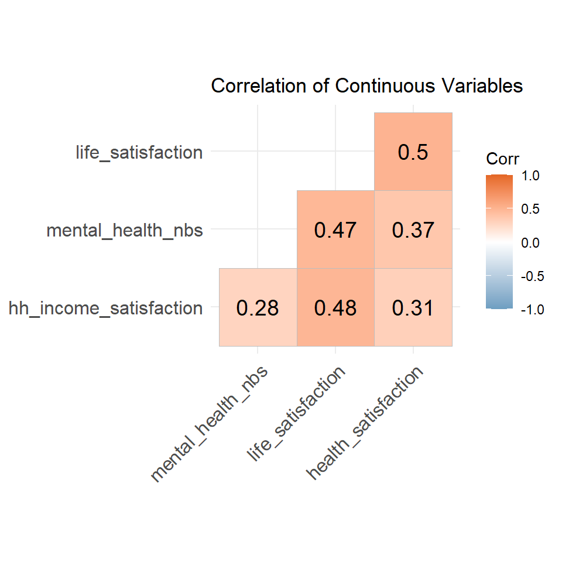

```r
# create a correlation matrix of continuous variables
cor_subset <- SOEP_clean %>%
  select(life_satisfaction, mental_health_nbs, health_satisfaction, hh_income_satisfaction) %>%
  na.omit()

# calculate the correlation
cor_matrix <- cor(cor_subset)

# create the "Lower Triangular" correlation plot
ggcorrplot(cor_matrix,
           hc.order = TRUE,
           type = "lower",     # This makes it the triangle shape
           lab = TRUE,          # This adds the numbers (0.5, 0.47, etc.)
           lab_size = 5,
           colors = c("#6D9EC1", "white", "#E46726"), # Blue to Orange scale
           title = "Correlation of Continuous Variables",
           ggtheme = theme_minimal())
```

### 2.4.3 Frequency Tables for Categorical Variables

```r
# frequency tables for categorical variables
cat_vars <- c("emp_status_harmonized", "emp_status_raw", "marital_status", "region", "education")

for (var in cat_vars) {
  cat("\n###", var, "\n")
  SOEP_clean %>%
    count(.data[[var]]) %>%
    mutate(pct = round(n / sum(n) * 100, 1)) %>%
    kable(caption = var) %>%
    print()
}
```

```
##
## ### emp_status_harmonized
##
##
## Table: emp_status_harmonized
##
## | emp_status_harmonized|     n|  pct|
## |---------------------:|-----:|----:|
## |                     1| 47994| 41.4|
## |                     2| 15891| 13.7|
## |                     3|  2400|  2.1|
## |                     4|  5844|  5.0|
## |                     5|   522|  0.5|
## |                     6|    48|  0.0|
## |                     7|   219|  0.2|
## |                     8|   141|  0.1|
## |                     9| 42865| 37.0|
## |                    12|    25|  0.0|
##
## ### emp_status_raw
##
##
## Table: emp_status_raw
##
## | emp_status_raw|     n|  pct|
## |--------------:|-----:|----:|
## |              0| 39515| 34.1|
## |              1| 76434| 65.9|
##
## ### marital_status
##
##
## Table: marital_status
##
## | marital_status|     n|  pct|
## |--------------:|-----:|----:|
## |              1| 70834| 61.1|
## |              2| 25150| 21.7|
## |              3|  7024|  6.1|
## |              4|  9945|  8.6|
```

[output cut: 20 more lines]

```
## |       8.5|   298|  0.3|
## |       9.0| 10732|  9.3|
## |      10.0|  3114|  2.7|
## |      10.5| 23372| 20.2|
## |      11.0|  5658|  4.9|
## |      11.5| 18665| 16.1|
## |      12.0| 13922| 12.0|
## |      13.0|  6772|  5.8|
## |      13.5|  1647|  1.4|
## |      14.0|  2490|  2.1|
## |      14.5|  3366|  2.9|
## |      15.0|  5309|  4.6|
## |      16.0|  5033|  4.3|
## |      17.0|   459|  0.4|
## |      18.0| 13642| 11.8|
```

# 3. Further Data Analysis

## 3.1 The Immediate Transition: Evidence of the “Honeymoon”

To understand the immediate shock of job loss, only the individuals who transitioned from employment in Year $t-1$ to unemployment in Year $t$ are isolated.

```r
# check mental health before and after being unemployed
# identify people who are actually employed (based on emp_status_harmonized)
employed_harmonized <- c(1, 2, 4, 12)  # only take full, part-time, marginal, short-time work
unemployed_raw <- 0                      # 0 = not employed / unemployed

transitions <- SOEP_clean %>%
  arrange(pid, syear) %>%   # sort data to check history chronologically
  group_by(pid) %>%
  mutate(
    employed_before = emp_status_harmonized %in% employed_harmonized,
    unemployed_now  = emp_status_raw == unemployed_raw,
    # lagged values to look at the previous survey year's values
    employed_prev   = dplyr::lag(employed_before),
    mh_prev         = dplyr::lag(mental_health_nbs),
    year_prev       = dplyr::lag(syear)
  ) %>%
  ungroup() %>%
  # transition: employed to unemployed
  # only where someone was employed last year and is unemployed this year
  filter(employed_prev, unemployed_now, !is.na(mh_prev), !is.na(mental_health_nbs)) %>%
  transmute(   # reshape to a clean table
    pid,
    year_before = year_prev,
    year_after  = syear,
    year_gap    = year_after - year_before,
    mh_before   = mh_prev,
    mh_after    = mental_health_nbs,
    mh_change   = mh_after - mh_before
  )

# simple OLS: Does 'before' predict 'after'?
ols_transition <- lm(mh_after ~ mh_before, data = transitions)

# testing the "Change" directly against a constant
# this will tell us if the average increase (mh_change) is significantly different from zero
ols_change <- lm(mh_change ~ 1, data = transitions)

summary(ols_change)
```

```
##
## Call:
## lm(formula = mh_change ~ 1, data = transitions)
##
## Residuals:
##     Min      1Q  Median      3Q     Max
## -49.331  -6.586  -0.479   5.627  36.160
##
## Coefficients:
##             Estimate Std. Error t value Pr(>|t|)
## (Intercept)   0.4794     0.1820   2.634  0.00847 **
## ---
## Signif. codes:  0 '***' 0.001 '**' 0.01 '*' 0.05 '.' 0.1 ' ' 1
##
## Residual standard error: 10.08 on 3069 degrees of freedom
```

```r
# paired t-test to confirm
t_test_res <- t.test(transitions$mh_after, transitions$mh_before, paired = TRUE)
```

Surprisingly, an OLS regression and a paired t-test reveal that mental health **increases** on average by 0.48 points immediately following job loss (*p* = 0.008). While statistically significant, a change of 0.48 is only about 0.04 SD in SF-12. A noticeable change would probably be 3 to 5. This initial bump supports the “Relief Effect”: if the previous employment was high-stress, leaving it temporarily benefits mental health.

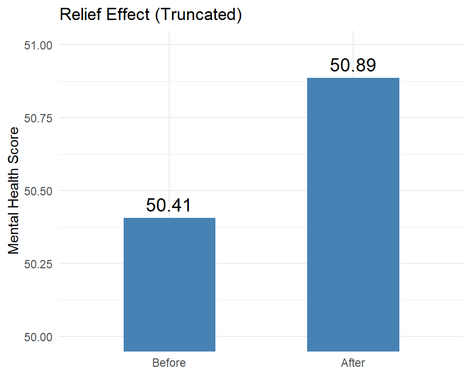

```r
# quickly plot the result
plot_data <- data.frame(
  Status = factor(c("Before", "After"), levels = c("Before", "After")),
  Avg_MH = c(mean(transitions$mh_before), mean(transitions$mh_after))
)

ggplot(plot_data, aes(x = Status, y = Avg_MH)) +
  geom_col(fill = "steelblue", width = 0.5) +
  # Add the specific values on top
  geom_text(aes(label = round(Avg_MH, 2)), vjust = -0.5, size = 5) +
  # Zoom the scale to see the difference clearly
  coord_cartesian(ylim = c(50, 51)) +
  theme_minimal() +
  labs(title = "Relief Effect (Truncated)", x = NULL, y = "Mental Health Score")
```

However, looking at the transition only gives a snapshot. It does not reveal anything about change over time.

## 3.2 Transition Over Time

Now, therefore let us take a look how it changes over time.

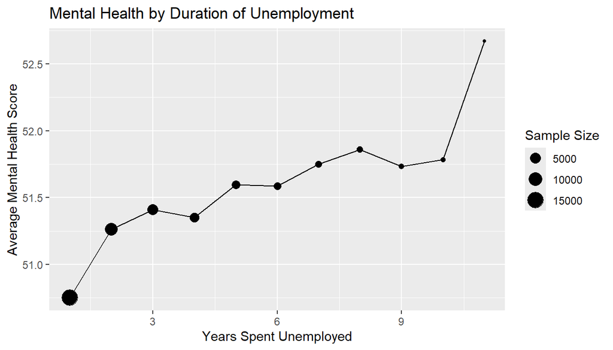

```r
# now let's check mental health over duration of unemployment
SOEP_arranged <- SOEP_clean %>%
  group_by(pid) %>%
  arrange(pid, syear) %>%
  mutate(
    # create the counter for consecutive years of unemployment
    is_unemployed         = (emp_status_raw == unemployed_raw),
    unemployment_duration = sequence(rle(is_unemployed)$lengths) * is_unemployed,

    # keep your original transition variables as well
    employed_before = emp_status_harmonized %in% employed_harmonized,
    employed_prev   = dplyr::lag(employed_before),
    mh_prev         = dplyr::lag(mental_health_nbs),
    year_prev       = dplyr::lag(syear)
  ) %>%
  ungroup()

# summary for the visualization
duration_analysis <- SOEP_arranged %>%
  filter(is_unemployed == TRUE) %>%
  group_by(unemployment_duration) %>%
  summarise(
    avg_mh = mean(mental_health_nbs, na.rm = TRUE),
    n_obs  = n()
  )

# plot the line (to show aggregate increase or decrease)
ggplot(duration_analysis, aes(x = unemployment_duration, y = avg_mh)) +
  geom_line() +
  geom_point(aes(size = n_obs)) +
  labs(title = "Mental Health by Duration of Unemployment",
       x = "Years Spent Unemployed",
       y = "Average Mental Health Score",
       size = "Sample Size")
```

```r
# shows increase in mental health over time
# but we don't know if these are the same people
# to see if the same person's mental health actually improves over time
# (rather than just the "unhappy" people leaving the sample), we use a Fixed Effects (FE) Model
```

We observe a noticeable increase over time. However, this is misleading as it suffers from **composition bias**: unhappy people might just be leaving the sample. To find out what happens to the *same person* over time, a **Fixed Effects (Within) Model** is used.

## 3.3 The Reality of Scarring: Fixed Effects Model

We now track the same people over time to make sure no composition bias is present.

```r
# FE model
fe_model <- plm(mental_health_nbs ~ unemployment_duration,
                data = SOEP_arranged,
                index = c("pid", "syear"),
                model = "within")

summary(fe_model)
```

```
## Oneway (individual) effect Within Model
##
## Call:
## plm(formula = mental_health_nbs ~ unemployment_duration, data = SOEP_arranged,
##     model = "within", index = c("pid", "syear"))
##
## Unbalanced Panel: n = 33846, T = 1-11, N = 115949
##
## Residuals:
##     Min.  1st Qu.   Median  3rd Qu.     Max.
## -39.0288  -3.0532   0.0000   3.3672  33.0629
##
## Coefficients:
##                        Estimate Std. Error t-value  Pr(>|t|)
## unemployment_duration -0.075747   0.020604 -3.6764 0.0002367 ***
## ---
## Signif. codes:  0 '***' 0.001 '**' 0.01 '*' 0.05 '.' 0.1 ' ' 1
##
## Total Sum of Squares:    4236200
## Residual Sum of Squares: 4235500
## R-Squared:      0.00016459
## Adj. R-Squared: -0.41201
## F-statistic: 13.5156 on 1 and 82102 DF, p-value: 0.00023674
```

```r
# now it appears, mental health indeed declines for individual by 0.074/y
# mental health score drops by about 0.075 points per year
```

Now, the Fixed Effects model, which tracks the **same person** over time, reveals that mental health declines by approximately **0.075 points per year** of unemployment. However, the R-squared is very low (0.00016), meaning it only explains a tiny fraction of changes. Other factors must be at play, which we will now examine.

## 3.4 Expanding the Model: Adding Controls

We add life satisfaction as the key outcome measure of overall well-being.

We include household income satisfaction to capture financial comfort, health satisfaction for physical/mental quality of life, and marital status plus number of children as core family support indicators.

Finally, we control for education (skills/background) and region (local economic/geographic factors).

```r
# let's see if other factors influence decline in mental health
# added new variables
SOEP_arranged_final <- SOEP_arranged %>%
  filter(marital_status != 7) %>%
  mutate(
    marital_status = factor(marital_status,
                            levels = c(1, 2, 3, 4, 5, 6),
                            labels = c("Married", "Single", "Widowed",
                                       "Divorced", "Separated", "NotWPartner")),
    region         = factor(region, levels = c(1, 2),
                            labels = c("West", "East")),
    education      = as.numeric(education),
    no_of_children = as.numeric(no_of_children)
  )

# run the model
fe_model_expanded <- plm(
  mental_health_nbs ~ unemployment_duration +
    life_satisfaction +
    hh_income_satisfaction +
    health_satisfaction +
    marital_status +
    no_of_children +
    education +
    region,
  data = SOEP_arranged_final,
  index = c("pid", "syear"),
  model = "within"
)
summary(fe_model_expanded)
```

```
## Oneway (individual) effect Within Model
##
## Call:
## plm(formula = mental_health_nbs ~ unemployment_duration + life_satisfaction +
##     hh_income_satisfaction + health_satisfaction + marital_status +
##     no_of_children + education + region, data = SOEP_arranged_final,
##     model = "within", index = c("pid", "syear"))
##
## Unbalanced Panel: n = 33846, T = 1-11, N = 115949
##
## Residuals:
##     Min.  1st Qu.   Median  3rd Qu.     Max.
## -36.4793  -3.0699   0.0000   3.2623  31.2079
##
## Coefficients:
##                          Estimate Std. Error t-value  Pr(>|t|)
## unemployment_duration    0.054710   0.019853  2.7557 0.0058575 **
## life_satisfaction        1.503870   0.020727 72.5556 < 2.2e-16 ***
## hh_income_satisfaction   0.166447   0.016521 10.0747 < 2.2e-16 ***
## health_satisfaction      0.779839   0.016423 47.4852 < 2.2e-16 ***
## marital_statusSingle    -0.485100   0.171664 -2.8259 0.0047165 **
## marital_statusWidowed   -1.825058   0.230417 -7.9207 2.392e-15 ***
## marital_statusDivorced   0.226967   0.196911  1.1526 0.2490619
## marital_statusSeparated -0.708373   0.211143 -3.3549 0.0007942 ***
## no_of_children          -0.395766   0.050483 -7.8396 4.572e-15 ***
## education                0.148653   0.057952  2.5651 0.0103166 *
## regionEast              -0.123719   0.343504 -0.3602 0.7187220
## ---
## Signif. codes:  0 '***' 0.001 '**' 0.01 '*' 0.05 '.' 0.1 ' ' 1
##
## Total Sum of Squares:    4236200
## Residual Sum of Squares: 3708800
## R-Squared:      0.12449
## Adj. R-Squared: -0.23658
## F-statistic: 1061.18 on 11 and 82092 DF, p-value: < 2.22e-16
```

```r
# compare R-squared
cat("Old R2:", summary(fe_model)$r.squared[1], "\n")
```

```
## Old R2: 0.0001645924
```

```r
cat("New R2:", summary(fe_model_expanded)$r.squared[1])
```

```
## New R2: 0.1244918
```

```r
# now, r-squared increased by nearly 800 times (from 0.01% to 12.4%)
```

## 3.5 Proving Non-Linearity: The Factor Model

As we previously found the coefficient -0.075 for the same person over time, but does it move in a straight line? To test this and to avoid forcing shape onto the data, each year of unemployment is treated as a separate categorical factor, letting the data show its own shape for each year.

```r
# as before we found the 0.074 coefficient
# does it actually decline in a straight line or it curves?
# to find out we can consider every year as unique event

# we can use a Fixed Effects model using Factors
# this way the data show its own shape for each year
fe_model_factor <- plm(
  mental_health_nbs ~ as.factor(unemployment_duration) +
    life_satisfaction + health_satisfaction + marital_status,
  data = SOEP_arranged_final,
  index = c("pid", "syear"),
  model = "within"
)

summary(fe_model_factor)
```

```
## Oneway (individual) effect Within Model
##
## Call:
## plm(formula = mental_health_nbs ~ as.factor(unemployment_duration) +
##     life_satisfaction + health_satisfaction + marital_status,
##     data = SOEP_arranged_final, model = "within", index = c("pid",
##         "syear"))
##
## Unbalanced Panel: n = 33846, T = 1-11, N = 115949
##
## Residuals:
##     Min.  1st Qu.   Median  3rd Qu.     Max.
## -37.0985  -3.0598   0.0000   3.2620  31.1771
##
## Coefficients:
##                                     Estimate Std. Error t-value  Pr(>|t|)
## as.factor(unemployment_duration)1   0.876554   0.088796  9.8715 < 2.2e-16 ***
## as.factor(unemployment_duration)2   1.265417   0.111888 11.3097 < 2.2e-16 ***
## as.factor(unemployment_duration)3   1.123918   0.128898  8.7194 < 2.2e-16 ***
## as.factor(unemployment_duration)4   0.902963   0.146333  6.1706 6.834e-10 ***
## as.factor(unemployment_duration)5   0.701349   0.166091  4.2227 2.417e-05 ***
## as.factor(unemployment_duration)6   0.689546   0.196463  3.5098 0.0004487 ***
## as.factor(unemployment_duration)7   0.712276   0.231993  3.0703 0.0021395 **
## as.factor(unemployment_duration)8   0.650384   0.269345  2.4147 0.0157509 *
## as.factor(unemployment_duration)9   0.577826   0.331584  1.7426 0.0814029 .
## as.factor(unemployment_duration)10  0.537372   0.428357  1.2545 0.2096651
## as.factor(unemployment_duration)11  2.238945   0.702981  3.1849 0.0014484 **
## life_satisfaction                   1.556572   0.020198 77.0647 < 2.2e-16 ***
## health_satisfaction                 0.787898   0.016326 48.2589 < 2.2e-16 ***
## marital_statusSingle               -0.390822   0.166130 -2.3525 0.0186494 *
## marital_statusWidowed              -1.606009   0.230802 -6.9584 3.468e-12 ***
## marital_statusDivorced              0.344768   0.196053  1.7585 0.0786582 .
## marital_statusSeparated            -0.610796   0.210243 -2.9052 0.0036713 **
## ---
## Signif. codes:  0 '***' 0.001 '**' 0.01 '*' 0.05 '.' 0.1 ' ' 1
##
## Total Sum of Squares:    4236200
## Residual Sum of Squares: 3709600
## R-Squared:      0.1243
## Adj. R-Squared: -0.23694
## F-statistic: 685.396 on 17 and 82086 DF, p-value: < 2.22e-16
```

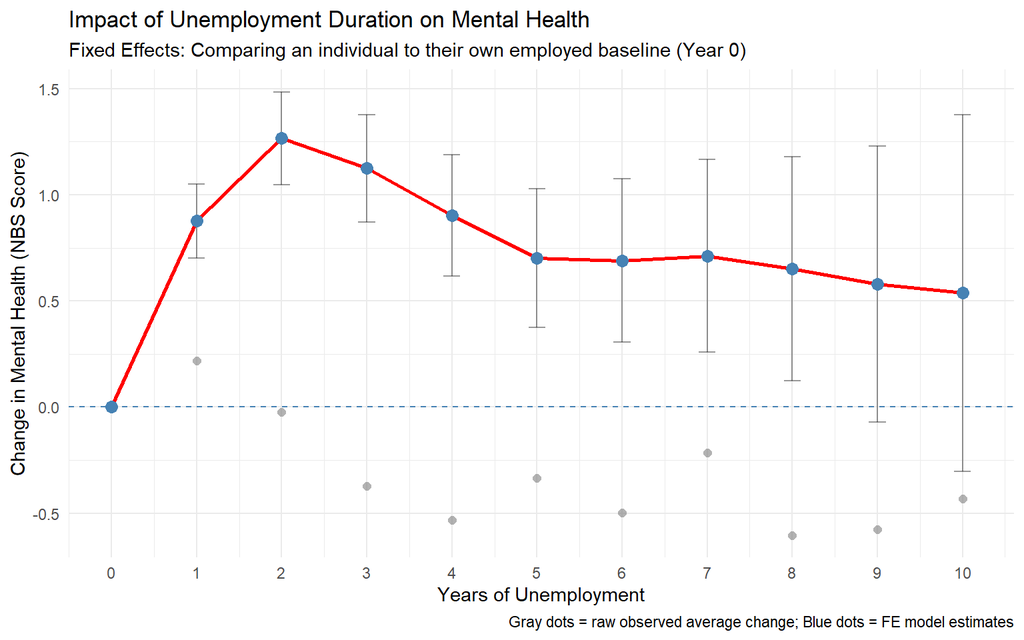

```r
# it is not linear
# let's see how it actually goes over time

# extract and clean the coefficients for plotting
coef_data <- tidy(fe_model_factor) %>%
  filter(grepl("unemployment_duration", term)) %>%
  mutate(
    # convert "as.factor(unemployment_duration)1" into just the number 1
    year      = as.numeric(gsub("as.factor\\(unemployment_duration\\)", "", term)),
    conf.low  = estimate - 1.96 * std.error,
    conf.high = estimate + 1.96 * std.error
  ) %>%
  filter(year <= 10) %>% # keep up to 10 years to avoid noise
  select(year, estimate, conf.low, conf.high)

# year 0 (the reference baseline where change is 0)
year_zero <- data.frame(year = 0, estimate = 0, conf.low = NA, conf.high = NA)
plot_data <- rbind(year_zero, coef_data)

# prepare raw data dots: average observed MH change per unemployment year
# using individuals who were employed the year before (mh_prev available)
raw_dots <- SOEP_arranged_final %>%
  filter(is_unemployed, unemployment_duration <= 10, !is.na(mh_prev)) %>%
  mutate(raw_change = mental_health_nbs - mh_prev) %>%
  group_by(unemployment_duration) %>%
  summarise(raw_change = mean(raw_change, na.rm = TRUE)) %>%
  rename(year = unemployment_duration)

# create plot
ggplot(plot_data, aes(x = year, y = estimate)) +
  geom_hline(yintercept = 0, linetype = "dashed", color = "steelblue") +
  # raw data dots in the background
  geom_point(data = raw_dots, aes(x = year, y = raw_change),
             color = "gray50", size = 2, alpha = 0.6, shape = 16) +
  geom_errorbar(aes(ymin = conf.low, ymax = conf.high), width = 0.2, alpha = 0.4,
                data = filter(plot_data, year != 0)) +
  geom_line(color = "red", linewidth = 1) +
  geom_point(color = "steelblue", size = 3) +
  scale_x_continuous(breaks = 0:10) +
  theme_minimal() +
  labs(
    title    = "Impact of Unemployment Duration on Mental Health",
    subtitle = "Fixed Effects: Comparing an individual to their own employed baseline (Year 0)",
    caption  = "Gray dots = raw observed average change; Blue dots = FE model estimates",
    x        = "Years of Unemployment",
    y        = "Change in Mental Health (NBS Score)"
  )
```

## 3.6 The Social Buffer: Marital Status Interaction

Since marriage appears to be a great factor here, we run an interaction model of `unemployment_duration * marital_status`. Because the effect is not a straight line, a quadratic term for `unemployment_duration` is included.

```r
# since marriage seem to be a great factor here
# we can do an interaction model of unemployment_duration * marital_status

# as we found earlier the effect is not straight line
# we will take the squared unemployment_duration

# interaction model
fe_interaction <- plm(
  mental_health_nbs ~ (unemployment_duration + I(unemployment_duration^2)) * marital_status +
    life_satisfaction + health_satisfaction,
  data  = SOEP_arranged_final,
  index = c("pid", "syear"),
  model = "within"
)
summary(fe_interaction)
```

```
## Oneway (individual) effect Within Model
##
## Call:
## plm(formula = mental_health_nbs ~ (unemployment_duration + I(unemployment_duration^2)) *
##     marital_status + life_satisfaction + health_satisfaction,
##     data = SOEP_arranged_final, model = "within", index = c("pid",
##         "syear"))
##
## Unbalanced Panel: n = 33846, T = 1-11, N = 115949
##
## Residuals:
##     Min.  1st Qu.   Median  3rd Qu.     Max.
## -37.1058  -3.0640   0.0000   3.2615  31.3519
##
## Coefficients:
##                                                      Estimate Std. Error
## unemployment_duration                               0.4600776  0.0556799
## I(unemployment_duration^2)                         -0.0535633  0.0068873
## marital_statusSingle                               -0.3659407  0.1673728
## marital_statusWidowed                              -1.2930995  0.3109970
## marital_statusDivorced                              0.3121981  0.2016014
## marital_statusSeparated                            -0.5379093  0.2283672
## life_satisfaction                                   1.5564911  0.0202090
## health_satisfaction                                 0.7902193  0.0163349
## unemployment_duration:marital_statusSingle         -0.1117170  0.1432321
## unemployment_duration:marital_statusWidowed        -0.4015168  0.1333751
## unemployment_duration:marital_statusDivorced       -0.0193132  0.1581853
## unemployment_duration:marital_statusSeparated      -0.1521148  0.2590603
## I(unemployment_duration^2):marital_statusSingle     0.0109333  0.0203582
## I(unemployment_duration^2):marital_statusWidowed    0.0495836  0.0148390
## I(unemployment_duration^2):marital_statusDivorced   0.0199811  0.0211228
## I(unemployment_duration^2):marital_statusSeparated  0.0078954  0.0365868
##                                                    t-value  Pr(>|t|)
## unemployment_duration                               8.2629 < 2.2e-16 ***
## I(unemployment_duration^2)                         -7.7771 7.508e-15 ***
## marital_statusSingle                               -2.1864 0.0287905 *
## marital_statusWidowed                              -4.1579 3.215e-05 ***
## marital_statusDivorced                              1.5486 0.1214841
## marital_statusSeparated                            -2.3555 0.0185022 *
## life_satisfaction                                  77.0199 < 2.2e-16 ***
## health_satisfaction                                48.3762 < 2.2e-16 ***
## unemployment_duration:marital_statusSingle         -0.7800 0.4354098
## unemployment_duration:marital_statusWidowed        -3.0104 0.0026095 **
## unemployment_duration:marital_statusDivorced       -0.1221 0.9028261
## unemployment_duration:marital_statusSeparated      -0.5872 0.5570850
## I(unemployment_duration^2):marital_statusSingle     0.5370 0.5912348
## I(unemployment_duration^2):marital_statusWidowed    3.3414 0.0008338 ***
## I(unemployment_duration^2):marital_statusDivorced   0.9459 0.3441780
## I(unemployment_duration^2):marital_statusSeparated  0.2158 0.8291445
## ---
## Signif. codes:  0 '***' 0.001 '**' 0.01 '*' 0.05 '.' 0.1 ' ' 1
##
## Total Sum of Squares:    4236200
## Residual Sum of Squares: 3713400
## R-Squared:      0.12343
## Adj. R-Squared: -0.23816
## F-statistic: 722.394 on 16 and 82087 DF, p-value: < 2.22e-16
```

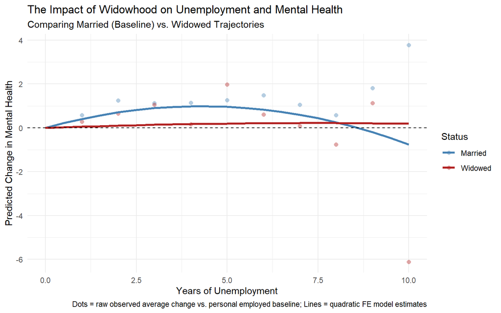

```r
# it appears that widowed people get almost zero relief from unemployment

# calculate each person's employed baseline MH (average MH while employed)
employed_baseline <- SOEP_arranged_final %>%
  filter(!is_unemployed) %>%
  group_by(pid) %>%
  summarise(baseline_mh = mean(mental_health_nbs, na.rm = TRUE))

# raw dots: observed MH vs personal baseline, by unemployment year and marital status
raw_dots <- SOEP_arranged_final %>%
  filter(is_unemployed, unemployment_duration <= 10,
         marital_status %in% c("Married", "Widowed")) %>%
  left_join(employed_baseline, by = "pid") %>%
  filter(!is.na(baseline_mh)) %>%
  mutate(mh_change = mental_health_nbs - baseline_mh) %>%
  group_by(unemployment_duration, marital_status) %>%
  summarise(raw_change = mean(mh_change, na.rm = TRUE), .groups = "drop") %>%
  rename(year = unemployment_duration, Status = marital_status)

# plot the result of interaction
coefs <- coef(fe_interaction)
years <- seq(0, 10, by = 0.5)

curve_data <- data.frame(year = years) %>%
  mutate(
    Married = (coefs["unemployment_duration"] * year) +
      (coefs["I(unemployment_duration^2)"] * year^2),
    Widowed = ((coefs["unemployment_duration"] + coefs["unemployment_duration:marital_statusWidowed"]) * year) +
      ((coefs["I(unemployment_duration^2)"] + coefs["I(unemployment_duration^2):marital_statusWidowed"]) * year^2)
  ) %>%
  pivot_longer(cols = -year, names_to = "Status", values_to = "Effect")

ggplot(curve_data, aes(x = year, y = Effect, color = Status)) +
  # raw dots in the background, matched by marital status color
  geom_point(data = raw_dots, aes(x = year, y = raw_change, color = Status),
             size = 2, alpha = 0.4, shape = 16) +
  geom_line(linewidth = 1.2) +
  geom_hline(yintercept = 0, linetype = "dashed") +
  theme_minimal() +
  scale_color_manual(values = c("Married" = "steelblue", "Widowed" = "firebrick")) +
  labs(
    title    = "The Impact of Widowhood on Unemployment and Mental Health",
    subtitle = "Comparing Married (Baseline) vs. Widowed Trajectories",
    caption  = "Dots = raw observed average change vs. personal employed baseline; Lines = quadratic FE model estimates",
    x        = "Years of Unemployment",
    y        = "Predicted Change in Mental Health"
  )
```

# 4. Conclusion

**Limitations:** While the Fixed Effects model controls for stable personal traits like natural optimism, it cannot account for unobserved *time-varying* shocks (like a sudden illness) that might occur simultaneously with job loss. Therefore, while the findings are robust, strict causality should be interpreted with caution.

Future policy interventions should not be “one-size-fits-all” but must prioritize immediate psychological support for socially isolated individuals entering unemployment.

# 5. References

Boswell, Wendy R, John W Boudreau, and Jan Tichy. 2005. “Employee Honeymoon and Hangover Effects: Are Job Changers More Satisfied Than Stayers?” *Academy of Management Journal* 48 (5): 882–99.

Clark, Andrew, Yannis Georgellis, and Peter Sanfey. 2001. “Scarring: The Psychological Impact of Past Unemployment.” *Economica* 68 (270): 221–41.

Hetschko, Clemens, Andreas Knabe, and Ronnie Schöb. 2014. “Changing Identity: Retiring from Unemployment.” *The Economic Journal* 124 (575): 149–66.

Stroebe, Margaret, Henk Schut, and Wolfgang Stroebe. 2007. “Health Outcomes of Bereavement.” *The Lancet* 370 (9603): 1960–73.

Young, Collin. 2012. “The State of the Art: A Review of Social Support and Unemployment.” *Journal of Economic Psychology* 33 (1): 124–38.